# R Notebook

```r
# librerias

library(survival)
library(KMsurv)
library(actuar)
library(BGPhazard)
library(rmutil)
```

```r
#Datos locomotora
#-Eschmee & Nelson (1977): The number of thousand miles-
#-at which different locomotive controls failed.-
time<-c(22.5,37.5,46,48.5,51.5,53,54.5,57.5,66.5,68,
        69.5,76.5,77,78.5,80,81.5,82,83,84,91.5,93.5,102.5,
        107,108.5,112.5,113.5,116,117,118.5,119,120,122.5,123,
        127.5,131,132.5,134,rep(135,59))
        delta<-c(rep(1,37),rep(0,59))
locomotive<-data.frame(time=time,delta=delta)
```

Estimador Kaplan Meier

```r
t<-Surv(locomotive$time,locomotive$delta)

#--- Estimador KM ---
#Calculo del estimador
xfit<-survfit(t~1)
xfit2<-survfit(t~1,conf.type="plain")
xfit3<-survfit(t~1,conf.type="log-log")
#Presentacion de estimador
print(xfit)
```

```
Call: survfit(formula = t ~ 1)

      n  events  median 0.95LCL 0.95UCL
     96      37      NA      NA      NA
```

```r
summary(xfit)
```

```
Call: survfit(formula = t ~ 1)

  time n.risk n.event survival std.err lower 95% CI upper 95% CI
  22.5     96       1    0.990  0.0104        0.969        1.000
  37.5     95       1    0.979  0.0146        0.951        1.000
  46.0     94       1    0.969  0.0178        0.935        1.000
  48.5     93       1    0.958  0.0204        0.919        0.999
  51.5     92       1    0.948  0.0227        0.904        0.993
  53.0     91       1    0.938  0.0247        0.890        0.987
  54.5     90       1    0.927  0.0265        0.877        0.981
  57.5     89       1    0.917  0.0282        0.863        0.974
  66.5     88       1    0.906  0.0297        0.850        0.966
  68.0     87       1    0.896  0.0312        0.837        0.959
  69.5     86       1    0.885  0.0325        0.824        0.951
  76.5     85       1    0.875  0.0338        0.811        0.944
  77.0     84       1    0.865  0.0349        0.799        0.936
  78.5     83       1    0.854  0.0360        0.786        0.928
  80.0     82       1    0.844  0.0371        0.774        0.920
  81.5     81       1    0.833  0.0380        0.762        0.911
  82.0     80       1    0.823  0.0390        0.750        0.903
  83.0     79       1    0.812  0.0398        0.738        0.894
  84.0     78       1    0.802  0.0407        0.726        0.886
  91.5     77       1    0.792  0.0414        0.714        0.877
  93.5     76       1    0.781  0.0422        0.703        0.868
 102.5     75       1    0.771  0.0429        0.691        0.860
 107.0     74       1    0.760  0.0436        0.680        0.851
 108.5     73       1    0.750  0.0442        0.668        0.842
 112.5     72       1    0.740  0.0448        0.657        0.833
 113.5     71       1    0.729  0.0454        0.645        0.824
 116.0     70       1    0.719  0.0459        0.634        0.815
 117.0     69       1    0.708  0.0464        0.623        0.805
 118.5     68       1    0.698  0.0469        0.612        0.796
 119.0     67       1    0.688  0.0473        0.601        0.787
 120.0     66       1    0.677  0.0477        0.590        0.777
 122.5     65       1    0.667  0.0481        0.579        0.768
 123.0     64       1    0.656  0.0485        0.568        0.758
 127.5     63       1    0.646  0.0488        0.557        0.749
 131.0     62       1    0.635  0.0491        0.546        0.739
 132.5     61       1    0.625  0.0494        0.535        0.730
 134.0     60       1    0.615  0.0497        0.525        0.720
```

```r
#Grafica del estimador
par(mfrow=c(1,3))
plot(xfit,conf.int=TRUE, lty=c(1,2,2),col=c(1,2,2))
plot(xfit2,conf.int=TRUE,lty=c(1,2,2),col=c(1,2,2))
```

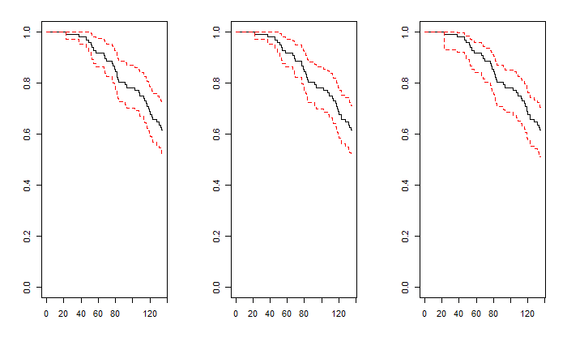

```r
plot(xfit3,conf.int=TRUE,lty=c(1,2,2),col=c(1,2,2))
```

```r
#Informacion que contiene el objeto xfit
names(xfit)
```

```
 [1] "n"          "time"       "n.risk"     "n.event"    "n.censor"   "surv"       "std.err"    "cumhaz"     "std.chaz"   "start.time"
[11] "type"       "logse"      "conf.int"   "conf.type"  "lower"      "upper"      "call"
```

Estimacion

```r
print(xfit, rmean = 135) #media cortada hasta el tiempo 135
```

```
Call: survfit(formula = t ~ 1)

         n     events     *rmean *se(rmean)     median    0.95LCL    0.95UCL
     96.00      37.00     117.42       2.96         NA         NA         NA
    * restricted mean with upper limit =  135
```

ESTIMADOR BAYESIANO

[figure not shown]

[figure not shown]

```r
#plot
BePloth(xfitB)
```